## Raunak kumari

Stock Price analysis -2024

Only for educational purpose

# Requirement

1.should have completed linear regression

2.Should have completed SVM

In this project we will develop stock price predictor using only these two predictors.

```python
import numpy as np
import pandas as pd
import yfinance as yf
import matplotlib.pyplot as plt  #visulaization lib
import seaborn as sns #visualization libraries

%matplotlib inline
```

yf.download() is a function provided by the yfinance library that downloads historical stock price data from Yahoo Finance.

auto_adjust=True: This argument adjusts the stock prices for any corporate actions (such as stock splits or dividends) that occurred during the specified time period.

The auto_adjust=True argument in the yf.download() function of the yfinance library adjusts the downloaded stock prices for any corporate actions that occurred during the specified time period. Here's how it works in detail:

Stock Splits: A stock split is when a company divides its existing shares into multiple shares. For example, in a 2-for-1 stock split, each existing share is split into two shares. Stock splits are intended to make shares more affordable for investors and increase liquidity.

Adjusting Stock Prices: When you set auto_adjust=True, the yfinance library automatically adjusts the downloaded stock prices to account for stock splits and dividends. Here's how it works:

Stock Splits: If a stock split occurred during the specified time period, the historical stock prices are adjusted by dividing the historical prices by the split ratio. For example, if there was a 2-for-1 stock split, the historical prices would be divided by 2. Why Adjust Prices: Adjusting stock prices for corporate actions allows for a more accurate analysis of historical stock performance. It ensures that the historical prices reflect the true value of the stock and are not skewed by events such as stock splits or dividends.

In summary, setting auto_adjust=True in the yf.download() function ensures that the downloaded stock prices are adjusted for any stock splits or dividends that occurred during the specified time period, providing a more accurate representation of the stock's historical performance.

```python
stocks = input("Enter the code of the stock")
data= yf.download(stocks,"2020-05-10","2024-05-12",auto_adjust= True)
data.head()
```

```
Enter the code of the stockAIZ
```

```
[*********************100%%**********************]  1 of 1 completed
```

| Date | Open | High | Low | Close | Volume |
| --- | --- | --- | --- | --- | --- |
| 2020-05-11 | 90.529388 | 91.854435 | 88.463061 | 91.178017 | 477900 |
| 2020-05-12 | 91.224370 | 91.595014 | 86.257761 | 86.267029 | 536700 |
| 2020-05-13 | 85.488674 | 85.636927 | 80.410870 | 81.318947 | 1018700 |
| 2020-05-14 | 80.049499 | 82.745926 | 77.732984 | 82.514275 | 669700 |
| 2020-05-15 | 81.550603 | 84.487943 | 80.383077 | 84.423080 | 1931200 |

```python
data.shape # no of rows and no of columne, numpy library
```

```
(1008, 5)
```

```python
data.describe()
```

|  | Open | High | Low | Close | Volume |
| --- | --- | --- | --- | --- | --- |
| count | 1008.000000 | 1008.000000 | 1008.000000 | 1008.000000 | 1.008000e+03 |
| mean | 142.040500 | 143.473259 | 140.575805 | 142.014408 | 4.168516e+05 |
| std | 22.941429 | 23.014402 | 22.898115 | 22.954193 | 2.101255e+05 |
| min | 80.049499 | 82.745926 | 77.732984 | 81.318947 | 8.670000e+04 |
| 25% | 123.908548 | 125.261837 | 122.627334 | 124.021452 | 2.919250e+05 |
| 50% | 145.044279 | 146.490412 | 143.615397 | 144.990288 | 3.659000e+05 |
| 75% | 159.678138 | 161.405215 | 158.609733 | 159.961121 | 4.733750e+05 |
| max | 187.820007 | 189.479996 | 187.380005 | 188.240005 | 1.931200e+06 |

In data analysis, the describe() method in pandas is used to generate descriptive statistics of a DataFrame or Series. It provides a summary of the central tendency, dispersion, and shape of the dataset's distribution, excluding NaN values.

```python
data.info()  # summary of dataframe
```

```
<class 'pandas.core.frame.DataFrame'>
DatetimeIndex: 1008 entries, 2020-05-11 to 2024-05-10
Data columns (total 5 columns):
 #   Column  Non-Null Count  Dtype
---  ------  --------------  -----
 0   Open    1008 non-null   float64
 1   High    1008 non-null   float64
 2   Low     1008 non-null   float64
 3   Close   1008 non-null   float64
 4   Volume  1008 non-null   int64
dtypes: float64(4), int64(1)
memory usage: 47.2 KB
```

data.Close: Accesses the 'Close' column of the data DataFrame, which presumably contains the closing prices of the stock.

.plot(): Plots the data as a line plot.

figsize=(10, 7): Sets the size of the figure to 10 inches in width and 7 inches in height.

color='r': Sets the color of the line to red ('r'). plt.ylabel(): Sets the label for the y-axis.

"{} Prices".format(stocks): Uses string formatting to dynamically set the y-axis label to include the stock code or name (stored in the stocks variable).

plt.show():

Displays the plot.

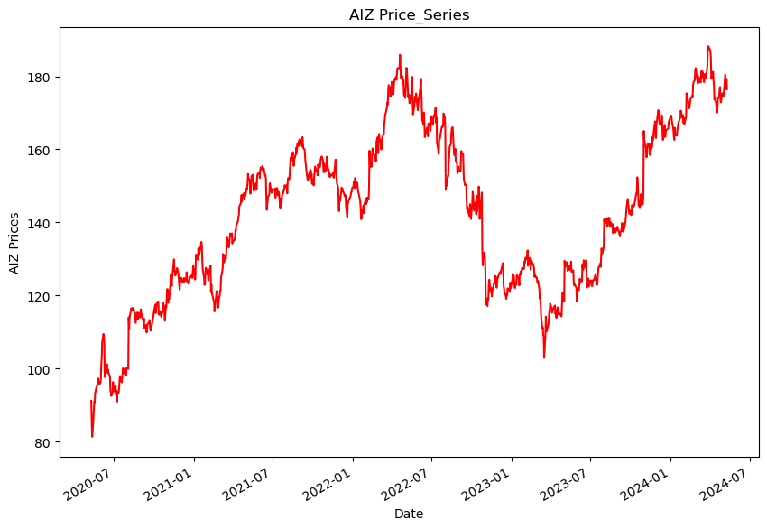

```python
data.Close.plot(figsize =(10,7),color='r')
plt.ylabel("{} Prices".format(stocks))
plt.title("{} Price_Series".format(stocks))
plt.show()
```

# very very non-linear

The sns.displot(data["Close"]) function uses the Seaborn library to create a histogram of the 'Close' prices of a stock

sns.displot(): This function is used to create a distribution plot (histogram) of the data.

data["Close"]: This selects the 'Close' column from the DataFrame data, assuming it contains the closing prices of a stock. The column is used as the data for the histogram.

Result: The displot() function will generate a histogram showing the distribution of the closing prices. Each bar in the histogram represents a range of closing prices, and the height of the bar indicates the frequency or number of occurrences of closing prices within that range.

Customization: You can customize the plot further by adding parameters to the displot() function. For example, you can specify the number of bins for the histogram (bins parameter), the color of the bars (color parameter), or the title of the plot (title parameter).

Overall, sns.displot(data["Close"]) is a simple way to visualize the distribution of closing prices of a stock, which can be helpful in understanding the typical price range and frequency of price movements.

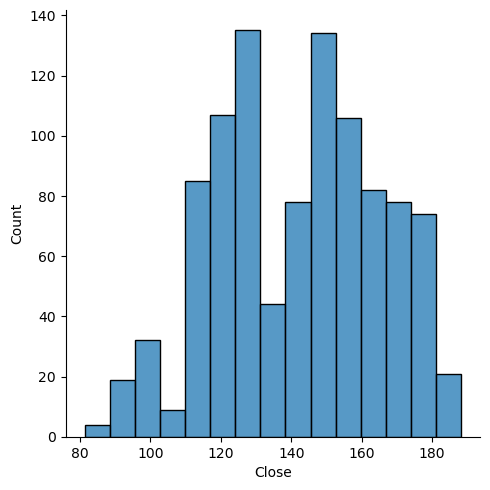

```python
sns.displot(data["Close"])
```

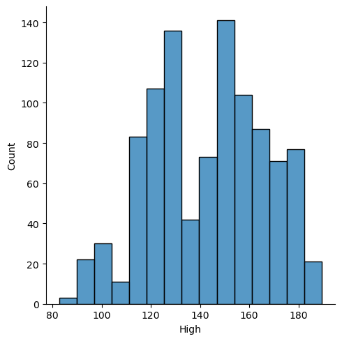

```python
sns.displot(data["High"])
```

This code snippet demonstrates how to prepare data for a machine learning model using the scikit-learn library (sklearn). It specifically focuses on splitting the data into training and testing sets. Here's a detailed explanation of each part:

x = data.drop("Close", axis=1) and y = data["Close"]:

x: This variable holds the features (independent variables) used to predict the target variable. y: This variable holds the target variable (dependent variable) that you want to predict.

train_test_split(x, y, test_size=0.2, random_state=0):

x and y: These are the feature and target variable datasets that you want to split.

test_size=0.2: This parameter specifies the proportion of the dataset to include in the test split. Here, 20% of the data will be used for testing, and the remaining 80% will be used for training.

random_state=0: This parameter sets the random seed for reproducibility. Setting a random seed ensures that the split is deterministic and will produce the same results each time the code is run.

The function returns four arrays:

x_train: The training data features.

x_test: The testing data features.

y_train: The training data target variable.

y_test: The testing data target variable.

```python
x = data.drop("Close", axis=1)
y = data["Close"]

from sklearn.model_selection import train_test_split

x_train, x_test, y_train, y_test  = train_test_split(x,y, test_size=0.2, random_state =0 ) #data will not change random_state


print(x_train.shape)
print(x_test.shape)
print(y_train.shape)
print(y_test.shape)
```

```
(806, 4)
(202, 4)
(806,)
(202,)
```

This code snippet demonstrates how to train a linear regression model using scikit-learn (sklearn). Here's a detailed explanation of each part:

These lines import the LinearRegression and SVR (Support Vector Regressor) classes from the sklearn.linear_model and sklearn.svm modules, respectively. LinearRegression is used for linear regression, while SVR is a type of Support Vector Machine model used for regression.

lr = LinearRegression():

This line creates an instance of the LinearRegression class, which will be used to train a linear regression model.

lr.fit(x_train, y_train):

This line trains the linear regression model (lr) using the training data (x_train and y_train). x_train is the feature set used for training, and y_train is the target variable (i.e., the actual values you want to predict).

pred1 = lr.predict(x_test):

This line uses the trained linear regression model (lr) to make predictions on the test data (x_test).

The predicted values are stored in the pred1 variable.

```python
from sklearn.linear_model import LinearRegression
from sklearn.svm import SVR

lr = LinearRegression()
lr.fit(x_train, y_train)

pred1 = lr.predict(x_test)
```

```python
pred1
```

```
array([123.87226635, 147.59247144, 112.1933158 , 145.28758998,
       121.83293577, 137.20150191,  87.62000466, 129.65481417,
       163.25283222, 143.32195793, 143.40326294,  99.36960664,
       142.34145267, 166.28782757, 158.51660861, 119.71434167,
       148.60620672, 172.28468308, 121.12450603, 149.85160428,
       182.59771588,  96.2085427 , 181.14776218, 180.34128528,
       149.79648271, 112.2578862 , 129.36756953, 157.14303875,
       148.32671904, 144.03985216, 144.81356931, 163.8500613 ,
        94.52593895, 116.38752354,  95.91440834, 115.20883014,
       153.12051504, 154.96109165, 179.24308271, 163.71400259,
       125.57323316, 168.70440468, 100.1110093 , 130.87780566,
       126.40960432, 138.36808619, 116.50526642, 150.48215636,
       154.64285806, 114.63595328, 156.0721818 , 119.2727935 ,
       121.8327495 , 178.95385275, 122.94179171, 115.91463938,
       156.46780641, 138.71692544, 172.23084268, 157.81330448,
       153.94804619, 123.30773182, 180.93272642, 163.15011277,
       156.50983209, 145.25656882, 119.39648964, 158.65874632,
       172.07859582, 113.17591827, 172.4498057 , 115.18421885,
       120.35126662, 149.78669683, 130.79694941, 167.80258857,
       162.52989951, 154.4927695 , 160.16917447, 124.28303553,
       114.18593659, 159.72618378, 173.03920408, 170.02581931,
       150.70518775, 180.14357253, 115.44857975, 162.74107882,
       149.75762619, 174.35416841, 146.51832556, 152.98069048,
       154.45755208, 179.81114064, 146.87095525, 170.69720859,
       155.15572503, 123.58164732, 134.72144938, 142.99775986,
       166.26223862, 155.68799252, 152.39482762, 130.31296484,
       164.01881394, 175.62261965, 126.87980368, 175.99199009,
       155.04495291, 143.66291073, 117.26173556, 145.23821972,
       138.32980798, 149.6696987 , 123.54626994, 160.91991095,
       140.06254967, 139.73217508, 125.23170865, 113.26425294,
       158.0272499 , 122.06302277, 153.95020481, 170.17299673,
       183.05383725, 152.3869559 , 147.65404238, 168.39649562,
       129.44896165, 147.89992991, 112.64655122, 148.59182699,
       103.91664986, 145.14977962, 178.83418302, 132.67409957,
       148.02400151, 164.16124453, 106.70729728, 125.0575782 ,
       158.14402679, 135.72718104,  94.51389117, 159.59241212,
       139.73483032, 115.66065225, 144.92106355, 179.22271043,
       171.09808491, 180.28928684, 140.89191873, 154.26306564,
       168.8674461 ,  99.14819844,  93.54363544, 158.08430441,
        98.27848255, 166.54062499, 128.37775428, 172.12203247,
       145.5885343 , 165.49574211, 179.04799861, 166.4105504 ,
       150.83205315, 173.53860641, 121.80868578, 168.36082961,
       128.22709233, 165.04220396, 178.1852355 , 157.3616133 ,
       176.1671275 , 129.75981606, 123.92394811, 154.72440071,
       152.28981032, 124.78439082, 124.64838997, 177.84362524,
       127.47121941, 175.85743754, 149.4486791 , 154.5175361 ,
       145.24988654, 124.84784844, 122.21234307, 177.94199796,
       140.28551008, 155.69410504, 147.59457249, 180.92458227,
       112.38861897, 149.7072648 , 151.71167012, 165.23852551,
       169.24227177, 129.10108357, 139.62765146,  91.06227642,
       155.32482308, 127.38977159])
```

from sklearn.metrics import mean_squared_error, r2_score:

These lines import the mean_squared_error and r2_score functions from the sklearn.metrics module. These functions are used to calculate the MSE and R2 score, respectively. def calculate_metrics(y_test, y_pred)::

This line defines a function calculate_metrics that takes two arguments: y_test (the actual target values) and y_pred (the predicted values). Calculating Metrics:

print("MSE is", mse): This line prints the calculated MSE. print("RMSE is", rmse): This line prints the calculated RMSE. print("R2 score is", r2_scor): This line prints the calculated R2 score. calculate_metrics(y_test, pred1):

This line calls the calculate_metrics function with the y_test values (actual target values) and pred1 (predicted values from the linear regression model).

```python
#MSE
#RMSE
#r2 Square

from sklearn.metrics import mean_squared_error, r2_score


def calculate_metrics(y_test,y_pred):

    mse = mean_squared_error(y_test,y_pred)
    rmse = np.sqrt(mse)
    r2_scor =r2_score(y_test ,y_pred)   #y_test = ground truth and y-pred = model predicted value

    print("MSE is", mse)
    print("RMSE is", rmse)
    print("R2 score is", r2_scor)

calculate_metrics(y_test, pred1)
```

```
MSE is 0.7620049075303363
RMSE is 0.8729289246727573
R2 score is 0.9985888647235063
```

from sklearn.linear_model import Lasso, Ridge:

These lines import the Lasso and Ridge classes from the sklearn.linear_model module. Lasso is used for Lasso regression, and Ridge is used for Ridge regression. la = Lasso().fit(x_train, y_train) and ri = Ridge().fit(x_train, y_train):

These lines create instances of the Lasso and Ridge classes and train them using the training data (x_train and y_train). la_p = la.predict(x_test) and ri_p = ri.predict(x_test):

These lines use the trained Lasso and Ridge models to make predictions on the test data (x_test). The predicted values are stored in la_p and ri_p, respectively. calculate_metrics(y_test, la_p):

```python
from sklearn.linear_model import Lasso,Ridge


la = Lasso().fit(x_train, y_train)
ri = Ridge().fit(x_train, y_train)

la_p = la.predict(x_test)
ri_p = ri.predict(x_test)


calculate_metrics(y_test, la_p)
```

```
MSE is 1.3410838473795796
RMSE is 1.15805174641705
R2 score is 0.9975164848584681
```

This code snippet demonstrates how to use GridSearchCV from scikit-learn (sklearn) to perform hyperparameter tuning for a Support Vector Regressor (SVR) model. Here's a detailed explanation of each part:

from sklearn.svm import SVR and from sklearn.model_selection import GridSearchCV:

These lines import the SVR class for Support Vector Regression and the GridSearchCV class for hyperparameter tuning using grid search, respectively. svr = SVR():

This line creates an instance of the SVR class, which will be used as the base model for hyperparameter tuning. params_grid:

This dictionary defines the grid of hyperparameters that will be searched. In this case, the grid includes values for C (regularization parameter), gamma (kernel coefficient), and kernel (kernel type). The values specified will be used to create different combinations of hyperparameters to search for the best combination. grid = GridSearchCV(SVR(), params_grid, refit=True, verbose=3):

This line creates an instance of GridSearchCV for hyperparameter tuning. The SVR() creates a new SVR instance, which is necessary because GridSearchCV needs a callable model to fit the data. params_grid is the grid of hyperparameters to search. refit=True specifies that the best estimator found during the grid search will be refit on the whole dataset. verbose=3 controls the verbosity of the output during the grid search process. A higher value (e.g., 3) provides more detailed output. grid.fit(x_train, y_train):

This line fits the GridSearchCV object to the training data (x_train and y_train). It performs the grid search by trying all possible combinations of hyperparameters and selecting the best combination based on cross-validated performance. After running this code, you can access the best hyperparameters and the best estimator using grid.best*params* and grid.best*estimator*, respectively. This tuned model can then be used to make predictions on new data.

```python
from sklearn.svm import SVR
from sklearn.model_selection import GridSearchCV

svr = SVR()

# Corrected the typo in the 'kernel' parameter
params_grid = {
    'C': [0.1, 1, 10, 100, 1000],
    'gamma': [1, 0.1, 0.01, 0.001, 0.0001],
    'kernel': ['rbf']  # Changed 'kernal' to 'kernel'
}

grid = GridSearchCV(SVR(), params_grid, refit=True, verbose=3)
grid.fit(x_train, y_train)
```

[output not shown]

[output cut: 71 more lines]

[output not shown]

```
GridSearchCV(estimator=SVR(),
             param_grid={'C': [0.1, 1, 10, 100, 1000],
                         'gamma': [1, 0.1, 0.01, 0.001, 0.0001],
                         'kernel': ['rbf']},
             verbose=3)
```

```python
svr = SVR(C =10, gamma= 0.01, kernel = 'rbf')
svr.fit(x_train, y_train)
svr_pred = svr.predict(x_test)
```

This code snippet demonstrates how to train a Support Vector Regressor (SVR) model with specific hyperparameters and use it to make predictions. Here's a detailed explanation of each part:

svr = SVR(C=10, gamma=0.01, kernel='rbf'):

This line creates an instance of the SVR class with specific hyperparameters: C=10: The regularization parameter. A larger C means less regularization. gamma=0.01: The kernel coefficient for 'rbf' kernel. A smaller gamma defines a larger similarity radius around each data point. kernel='rbf': Specifies the kernel type. 'rbf' stands for Radial Basis Function, which is a popular kernel for SVR. svr.fit(x_train, y_train):

This line fits the SVR model to the training data (x_train and y_train). The SVR model learns the relationship between the input features (x_train) and the target variable (y_train). svr_pred = svr.predict(x_test):

This line uses the trained SVR model to make predictions on the test data (x_test). The predicted values are stored in the svr_pred variable. Overall, this code snippet demonstrates how to create and train an SVR model with specific hyperparameters and use it to make predictions. SVR is a powerful technique for regression tasks, especially when dealing with non-linear relationships between features and target variables.

```python
import joblib

joblib.dump(ri,'model.pkl')

ridge_from_model =model= joblib.load("model.pkl")
```

This code snippet demonstrates how to use the joblib library in Python to save and load machine learning models. Here's a detailed explanation of each part:

import joblib:

This line imports the joblib module, which provides functions for saving and loading Python objects, including machine learning models. joblib.dump(ri, 'model.pkl'):

This line saves the trained Ridge regression model (ri) to a file named 'model.pkl'. The dump function serializes the object (ri) and saves it to a file using the pickle format (pkl). ridge_from_model = joblib.load("model.pkl"):

This line loads the saved model from the file 'model.pkl' back into memory. The load function deserializes the object from the file and assigns it to the variable ridge_from_model. After this line, ridge_from_model will contain the trained Ridge regression model that was saved and can be used for predictions or further analysis. In summary, this code snippet demonstrates how to save a trained machine learning model to a file and then load it back into memory for later use. This is useful for saving trained models and deploying them in production environments or sharing them with others.